# Reflections on NY Phil – The NY Phil as a lens on changes in US society

Around the turn of the century, New York City became the arts center of the world. Its establishment not only encouraged the flourishing of American musicians but also attracted musicians from all over the world to NYC. NY Philharmonic as an important art and culture institution, reflects the social and economic changes of the United States society over time. In this study I focus on NY Philharmonic data from three perspectives: 1. the nationality of composers whose works are performed by NY Philharmonic in relation to the political enviroments of the US; 2. the status of women composers over time; 3. the elasticity of an art and culture institute’s reaction to social issues by comparing NY Phil performance data and MoMA exhibition data.

### 1. Getting data from NY Philharmonic’s github page

First of all, I read the XML file from NY Philharmonic’s github page (https://github.com/nyphilarchive/PerformanceHistory/blob/master/Programs/complete.xml) and found the number of every composers whose work was performed for all seasons and put them in a table.

```r
require("XML")
require(mosaic)
xmlfile <- xmlParse("complete.xml",encoding="UTF-8")
rootnode = xmlRoot(xmlfile) #gives content of root

incrementComp <- function(composer_stats, c, season){
  if (is.null(composer_stats[c, season])) {
    composer_stats[c, season] <- 1
  } else if (is.na(composer_stats[c,season])) {
    composer_stats[c, season] <- 1
  } else {
    composer_stats[c, season] <- composer_stats[c, season] + 1
  }
  return(composer_stats)
}

composerBySeasonComplete <- data.frame()
for (seas in 1:xmlSize(rootnode)) {
  # DEBUG: cat(seas, "\n")
  firstlist <- xmlToList(rootnode[[seas]])
  season <- firstlist$season
  season <- paste("Season",season,sep=".")
  works <- firstlist$worksInfo
  if (is.list(works)) {     # sometimes works is actually empty
      for (i in 1:length(works)) {
        if (!is.null(works[[i]]$composerName)) {    #sometimes there is no composer
          composerBySeasonComplete <- incrementComp(composerBySeasonComplete, works[[i]]$composerName,season)
        }
      }
    }
}
colnames(composerBySeasonComplete)[1]="composers"
write.csv(composerBySeasonComplete, "composerBySeasonComplete.csv")
```

the cleaned data look like:

```r
composerBySeasonComplete <- read.csv("composerBySeasonComplete.csv", row.names=1, encoding="UTF-8")
composerBySeasonComplete[1:5,1:5]
```

```
##                    composers Season.1842.43 Season.1843.44 Season.1844.45
## 1    Beethoven,  Ludwig  van             12              4              8
## 2    Weber,  Carl  Maria Von             10              6              6
## 3            Hummel,  Johann              8              6              2
## 4        Rossini,  Gioachino              8              2             NA
## 5 Mozart,  Wolfgang  Amadeus              4              4              2
##   Season.1845.46
## 1              6
## 2              6
## 3             NA
## 4              6
## 5              6
```

To get a general sense of the data, I ordered composers by the number of works performed in descending order.

```r
SumComp=rowSums(composerBySeasonComplete[2:175],na.rm=TRUE)
SumComp=cbind(composerBySeasonComplete[1],SumComp)
SumComp1=SumComp[order(-SumComp$SumComp),]
```

The following graph shows that most of the composers’ works got performed fewer than ten times, and only 16 composers’ works are performed more than 1000 times. Therefore, I expect the composers to be diverse.

```r
require(mosaic)
nrow(SumComp1)
```

```
## [1] 2652
```

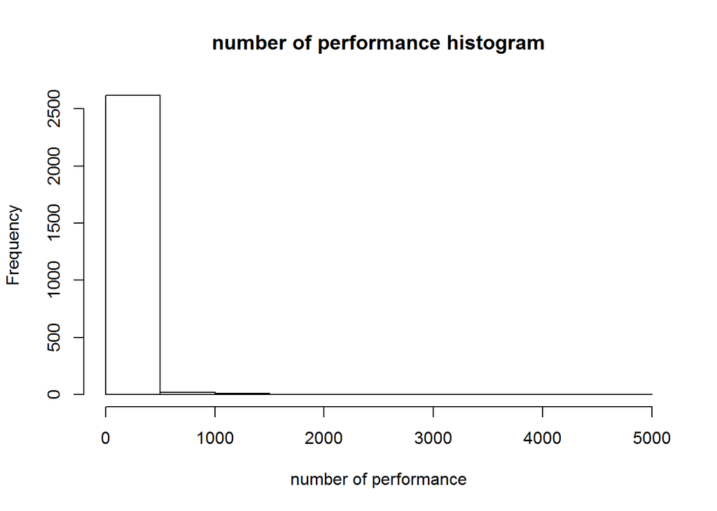

```r
hist(SumComp1$SumComp,main="number of performance histogram",xlab="number of performance")
```

```r
comp1000=subset(SumComp1,SumComp>=1000)
nrow(comp1000)
```

```
## [1] 16
```

```r
comp1000
```

```
##                           composers SumComp
## 81                 Wagner,  Richard    4942
## 1           Beethoven,  Ludwig  van    4509
## 163     Tchaikovsky,  Pyotr  Ilyich    3710
## 5        Mozart,  Wolfgang  Amadeus    2632
## 119               Brahms,  Johannes    2528
## 205               Strauss,  Richard    1624
## 15              Mendelssohn,  Felix    1514
## 37                 Berlioz,  Hector    1396
## 122        Bach,  Johann  Sebastian    1377
## 189 Dvorak,  Anton¨ªn    1212
## 770               Gershwin,  George    1129
## 56                 Schubert,  Franz    1124
## 400                 Ravel,  Maurice    1087
## 674              Prokofiev,  Sergei    1087
## 507               Stravinsky,  Igor    1085
## 359                Debussy,  Claude    1077
```

```r
compl1000=subset(SumComp1,SumComp<=10)
nrow(compl1000)
```

```
## [1] 2284
```

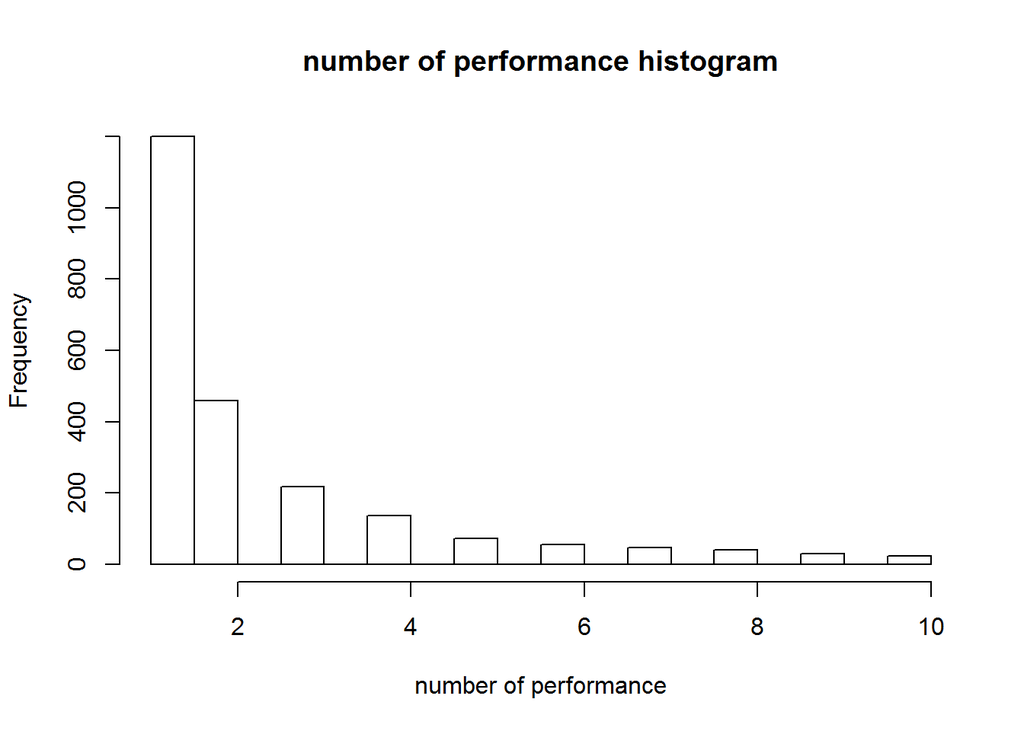

```r
hist(compl1000$SumComp,main="number of performance histogram",xlab="number of performance")
```

### 2. Number of Performance per year and economics

Graph of number of performance per year

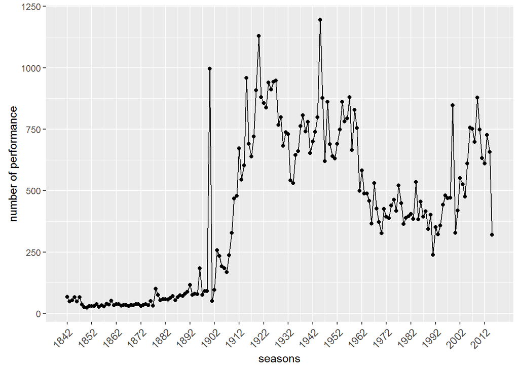

```r
SumSeas=colSums(composerBySeasonComplete[2:175],na.rm=TRUE)
require(ggplot2)
qplot(seq_along(as.double(SumSeas)),as.double(SumSeas))+geom_line()+ theme(axis.text.x = element_text(angle = 45,size=10, hjust = 1))+scale_x_continuous(breaks=seq(1,175,10),labels=c("1842","1852","1862","1872","1882","1892","1902","1912","1922","1932","1942","1952","1962","1972","1982","1992","2002","2012"))+ theme(axis.text.x = element_text(angle = 45,size=10, hjust = 1))+xlab("seasons")+ylab("number of performance")
```

### 3.Normalized Performance Frequency Score

Because the number of performance change year by year, I computed a “Normalized Performance Frequency Score” to normalize by total number of performances. I got the normalized performance frequency score by dividing the number of performances for each composers in each season by the total number of performance in each season.

```r
require(base)
composerBySeasonComplete[is.na(composerBySeasonComplete)] <- 0
composerBySeasonComplete1=composerBySeasonComplete[2:175]
composerBySeasonComplete2=composerBySeasonComplete[1]
popScoreComposerComplete=data.frame()
totalNumConcert=colSums(composerBySeasonComplete1, na.rm=TRUE)
for ( i in 1:2652){
  popScoreComposerComplete[i,]=composerBySeasonComplete1[i,]/totalNumConcert
  i=i+1
}
popScoreComposerComplete=cbind(composerBySeasonComplete2,popScoreComposerComplete)
write.csv(popScoreComposerComplete,"popScoreComposerComplete.csv")
```

the Normalized Performance Frequency Score table looks like:

```r
#popScoreComposerComplete <- read.csv("~/GitHub/azhangproject/popScoreComposerComplete.csv", row.names=1, encoding="UTF-8")
popScoreComposerComplete <- read.csv("popScoreComposerComplete.csv", row.names=1, encoding="UTF-8")
popScoreComposerComplete[1:5,1:5]
```

```
##                    composers Season.1842.43 Season.1843.44 Season.1844.45
## 1    Beethoven,  Ludwig  van     0.17647059     0.08333333     0.14814815
## 2    Weber,  Carl  Maria Von     0.14705882     0.12500000     0.11111111
## 3            Hummel,  Johann     0.11764706     0.12500000     0.03703704
## 4        Rossini,  Gioachino     0.11764706     0.04166667     0.00000000
## 5 Mozart,  Wolfgang  Amadeus     0.05882353     0.08333333     0.03703704
##   Season.1845.46
## 1     0.09090909
## 2     0.09090909
## 3     0.00000000
## 4     0.09090909
## 5     0.09090909
```

the top twenty list in the normalized performance frequency score table does not differ much from the composers by season table.

```r
popScoreSumComp=rowSums(popScoreComposerComplete[2:175],na.rm=TRUE)
popScoreSumComp=cbind(popScoreComposerComplete[1],popScoreSumComp)
popScoreSumComp1=popScoreSumComp[order(-popScoreSumComp$popScoreSumComp),]
head(popScoreSumComp1,20)
```

```
##                                           composers popScoreSumComp
## 1                           Beethoven,  Ludwig  van       14.753295
## 81                                 Wagner,  Richard       11.688653
## 5                        Mozart,  Wolfgang  Amadeus        7.586044
## 15                              Mendelssohn,  Felix        6.992933
## 163                     Tchaikovsky,  Pyotr  Ilyich        6.991802
## 119                               Brahms,  Johannes        4.885748
## 50                                Schumann,  Robert        4.197614
## 2                           Weber,  Carl  Maria Von        4.073181
## 37                                 Berlioz,  Hector        3.882389
## 98                                    Liszt,  Franz        3.574857
## 56                                 Schubert,  Franz        3.472880
## 122                        Bach,  Johann  Sebastian        3.287059
## 205                               Strauss,  Richard        2.885479
## 189                 Dvorak,  Anton¨ªn        2.624591
## 14                            Haydn,  Franz  Joseph        2.249149
## 39  Chopin,  Fr¨¦d¨¦ric        2.009401
## 74                        Handel,  George  Frideric        2.007217
## 674                              Prokofiev,  Sergei        1.965981
## 770                               Gershwin,  George        1.928257
## 507                               Stravinsky,  Igor        1.900496
```

```r
require(stringr)
```

```r
popScoreComposerComplete$composers=str_replace_all(popScoreComposerComplete$composers,"[^[:graph:]]", " ")
popScoreComposerComplete$composers=gsub("  ", " ", popScoreComposerComplete$composers, fixed = TRUE)

composerBySeasonComplete$composers=str_replace_all(composerBySeasonComplete$composers,"[^[:graph:]]", " ")
composerBySeasonComplete$composers=gsub("  ", " ", composerBySeasonComplete$composers, fixed = TRUE)
```

### 4.Composer Nationalities and Politics and Economy

art and politics can affect each other. In this part, I want to ask several questions:  
1. As NYC rise to be the center of art and culture, does the number of American composers’ works increase?  
2. Does the number of German composers’ work decrease during WWI and WwII?  
3. Does the number of Russian composers’ work decrease during the cold war?  
4. As the economy rises in Asian and Latin American countries, does the number of works from these areas increase over time?

To do this we need to identify the nationality of composers whose works are performed by the NY Philharmic. The NY Philharmonic data do not have the nationalities of composers. Therefore, I scraped wikipedia page and got data on composers’ nationalities. I got the most of the composers nationality scores by scraping this page and the links in the page: (https://en.wikipedia.org/wiki/Category:Classical_composers_by_nationality) using the following python code

```r
require(png)
require(grid)
```

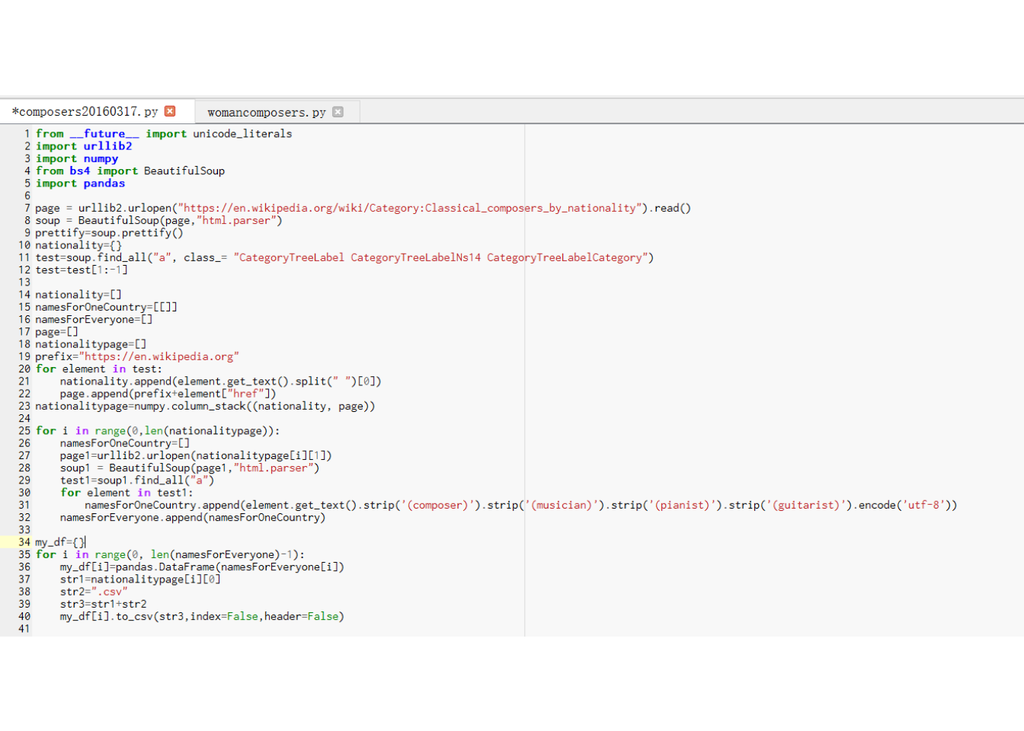

```r
img02 <- readPNG("2016-03-26b.png")
grid.raster(img02)
```

However, some pages, for example the American composer page (https://en.wikipedia.org/w/index.php?title=Category:American_classical_composers) has multiple pages, and it is hard to go through every page in my code. So I scraped every page by clicking by hand and rbind them together in R

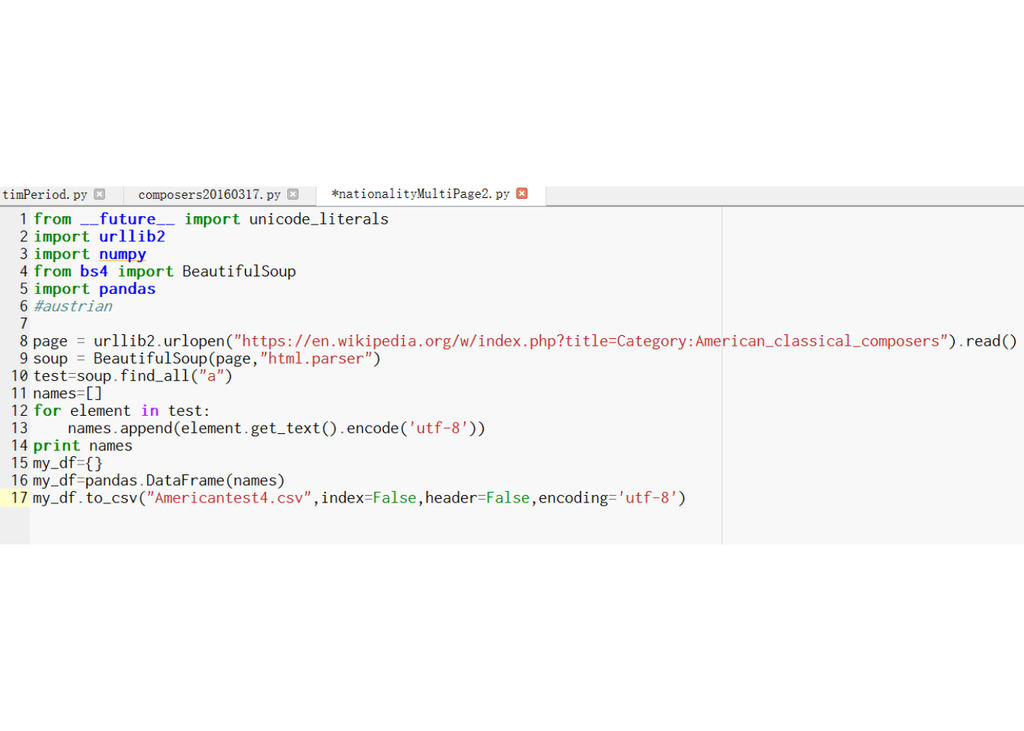

```r
img03 <- readPNG("scrapeNationality2.png")
grid.raster(img03)
```

Because there are many names that are written in different languages that don’t match easily to listings in the NY Phil record and wikipedia pages. I adapted a matching algorithm online to match names on Wikipedia page and NY Phil record. (http://www.r-bloggers.com/merging-data-sets-based-on-partially-matched-data-elements/)

```r
signature=function(x){
  sig=paste(sort(unlist(strsplit(tolower(x)," "))),collapse='')
  return(sig)
}

partialMatch=function(x,y,levDist=0.01){
  xx=data.frame(sig=sapply(x, signature),row.names=NULL)
  yy=data.frame(sig=sapply(y, signature),row.names=NULL)
  xx$raw=x
  yy$raw=y
  xx=subset(xx,subset=(sig!=''))
  xy=merge(xx,yy,by='sig',all=T)
  matched=subset(xy,subset=(!(is.na(raw.x)) & !(is.na(raw.y))))
  matched$pass="Duplicate"
  todo=subset(xy,subset=(is.na(raw.y)),select=c(sig,raw.x))
  colnames(todo)=c('sig','raw')
  todo$partials= as.character(sapply(todo$sig, agrep, yy$sig,max.distance = levDist,value=T))
  todo=merge(todo,yy,by.x='partials',by.y='sig')
  partial.matched=subset(todo,subset=(!(is.na(raw.x)) & !(is.na(raw.y))),select=c("sig","raw.x","raw.y"))
  partial.matched$pass="Partial"
  matched=rbind(matched,partial.matched)
  un.matched=subset(todo,subset=(is.na(raw.x)),select=c("sig","raw.x","raw.y"))
  if (nrow(un.matched)>0){
    un.matched$pass="Unmatched"
    matched=rbind(matched,un.matched)
  }
  matched=subset(matched,select=c("raw.x","raw.y","pass"))

  return(matched)
}
```

#### American.

I stacked the data from multiple pages, cleaned them and matched them with the normalized performance frequency score table and computed the proportion of the number of American composers whose works are performed by the NY Philharmonic over total number of works performed by the NY Philharmonic over time.

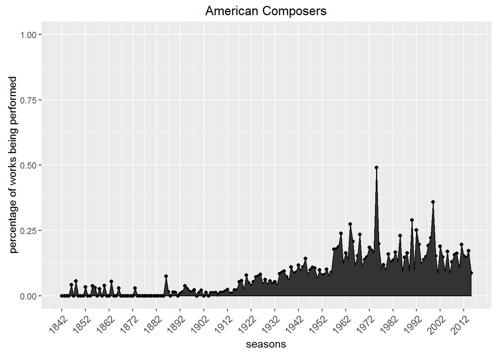

```r
american1=read.csv("americantest1.csv", header = FALSE ,encoding = "UTF-8")
american2=read.csv("americantest2.csv", header = FALSE ,encoding = "UTF-8")
american3=read.csv("americantest3.csv", header = FALSE ,encoding = "UTF-8")
american4=read.csv("americantest4.csv", header = FALSE ,encoding = "UTF-8")
american5=read.csv("americantest5.csv", header = FALSE ,encoding = "UTF-8")
american6=read.csv("americantest6.csv", header = FALSE ,encoding = "UTF-8")
american7=read.csv("americantest7.csv", header = FALSE ,encoding = "UTF-8")
american=c(american1,american2,american3,american4,american5,american6,american7)
american=unique(unlist(american))

american1.0=gsub("\\(composer)|\\(pianist)|\\(conductor)|\\(guitarist)|\\(musician)|\\ (musicologist)|\\(singer-songwriter)|\\ (Fluxus musician)","",american)
american1.1=strsplit(as.character(american1.0)," ")

american1.2=list(rep(0,length(american1.1)))
for ( i in 1:length(american1.1)){
  if (length(american1.1[[i]])>1)
    american1.2[i]=paste(american1.1[[i]][length(american1.1[[i]])],paste(american1.1[[i]][1:length(american1.1[[i]])-1], collapse=" "),sep=", ")
}
american1.2=american1.2[!is.na(american1.2)]
american1.4=unlist(american1.2)
american1.4=c(american1.4,"Gershwin, George")
american1.4=c(american1.4,"Bernstein, Leonard")
american1.4=c(american1.4,"Foote, Arthur")
require(ggplot2)

l=list(rep(0, length(american1.4)))
l=c()
for ( i in 1:length(american1.4)){
  l=c(l,which(american1.4[i]==popScoreComposerComplete$composers))
}
americans=popScoreComposerComplete$composers[l]
americansPop=popScoreComposerComplete[l,]
americansPopSum=colSums(americansPop[2:175])
qplot(seq_along(americansPopSum),americansPopSum)+geom_line()+ylim(0,1)+geom_area(colour="black")+scale_x_continuous(breaks=seq(1,175,10),labels=c("1842","1852","1862","1872","1882","1892","1902","1912","1922","1932","1942","1952","1962","1972","1982","1992","2002","2012"))+ theme(axis.text.x = element_text(angle = 45,size=10, hjust = 1))+xlab("seasons")+ylab("percentage of works being performed")+ggtitle("American Composers")
```

The graph shows a general increase of the proportion of the number of American composers over total number of composers over time which reinforces the hypothesis that as America rise to become the center of the art and culture of the world during the turn of the century its composers got more recognitions by the NY Philharmonic.

The top twenty American composers are

```r
americanTop=rowSums(americansPop[2:175],na.rm=TRUE)
americanTop=cbind(as.data.frame(americans)[1],americanTop)
americanTop1=americanTop[order(-americanTop$americanTop),]
head(americanTop1,20)
```

```
##                      americans americanTop
## 770           Gershwin, George   1.9282569
## 507           Stravinsky, Igor   1.9004960
## 749             Copland, Aaron   1.3986089
## 1193        Bernstein, Leonard   1.1988025
## 943             Barber, Samuel   0.4923890
## 301         Sousa, John Philip   0.4827266
## 795              Ives, Charles   0.4154716
## 1061          Schuman, William   0.2962214
## 533         Schoenberg, Arnold   0.2345309
## 40   Bristow, George Frederick   0.2287910
## 215            Herbert, Victor   0.2183539
## 937                Weill, Kurt   0.2026578
## 336      Hadley, Henry Kimball   0.1855457
## 781                Harris, Roy   0.1636104
## 1029             Gould, Morton   0.1421938
## 595              Bloch, Ernest   0.1269940
## 1516         Schuller, Gunther   0.1265823
## 389          Schelling, Ernest   0.1200423
## 231           Damrosch, Walter   0.1196747
## 1896            Williams, John   0.1121302
```

#### Germany

```r
german1=read.csv("germantest1.csv", header = FALSE ,encoding = "UTF-8")
german2=read.csv("germantest2.csv", header = FALSE ,encoding = "UTF-8")
german3=read.csv("germantest3.csv", header = FALSE ,encoding = "UTF-8")
german4=read.csv("germantest4.csv", header = FALSE ,encoding = "UTF-8")
german5=read.csv("germantest5.csv", header = FALSE ,encoding = "UTF-8")


german=c(german1,german2,german3,german4,german5)
german=unique(unlist(german))
german1.0=gsub("\\(composer)","",german)
german1.0=gsub("\\(baroque composer)","",german1.0)
german1.0=gsub("\\(Altstadt Kantor)","",german1.0)
german1.0=gsub("\\(Morean)","",german1.0)
german1.0=gsub("\\(1772???1806)","",german1.0)
german1.0=gsub("\\(conductor)","",german1.0)
german1.0=gsub("\\(the elder)","",german1.0)
german1.0=gsub("\\(the younger)","",german1.0)
german1.0=gsub("\\(musician)","",german1.0)
german1.0=gsub("\\(organist)","",german1.0)
german1.0=gsub("\\(guitarist)","",german1.0)
german1.0=gsub("\\(musician at Arnstadt)","",german1.0)
german1.0=gsub("\\(Austrian composer)","",german1.0)
german1.1=strsplit(as.character(german1.0)," ")

german1.2=list(rep(0,length(german1.1)))
for ( i in 1:length(german1.1)){
  if (length(german1.1[[i]])>1){
    german1.2[i]=paste(german1.1[[i]][length(german1.1[[i]])],paste(german1.1[[i]][1:length(german1.1[[i]])-1], collapse=" "),sep=", ")
  }
}
german1.2=german1.2[!is.na(german1.2)]

test2=partialMatch(popScoreComposerComplete$composers,german1.2)
test3=test2[-c(126,130,142,141,138),]
german1.3=test3$raw.x
save(german1.3,file="germanComps.RData")
```

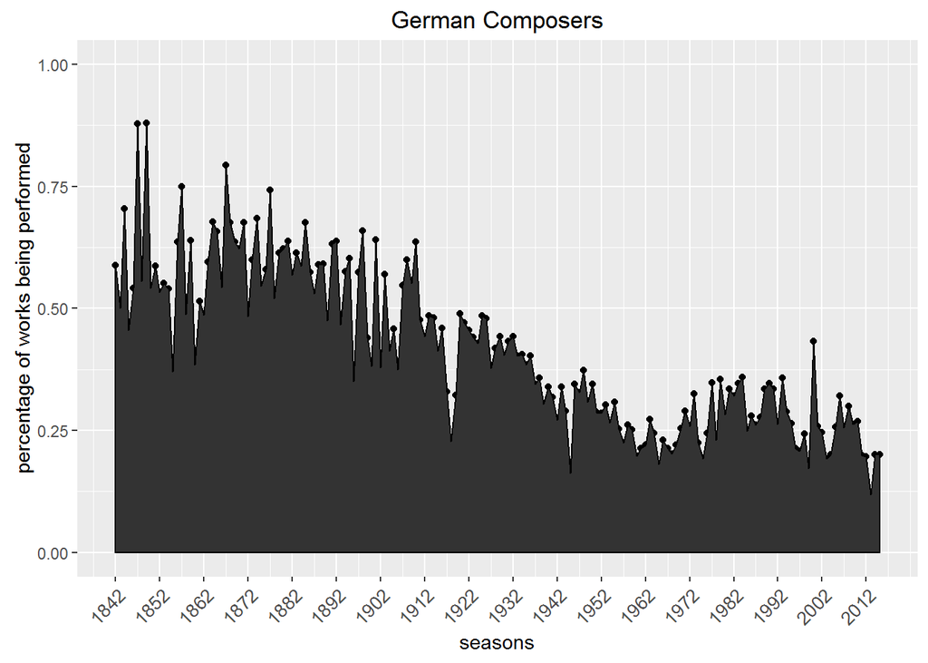

```r
load("germanComps.RData")

l=c()
for ( i in 1:length(german1.3)){
  l=c(l,which(german1.3[i]==popScoreComposerComplete$composers))
}
german=popScoreComposerComplete$composers[l]
germanPop=popScoreComposerComplete[l,]
germanPopSum=colSums(germanPop[2:175])
qplot(seq_along(germanPopSum),germanPopSum)+geom_line()+ylim(0,1)+geom_area(colour="black")+scale_x_continuous(breaks=seq(1,175,10),labels=c("1842","1852","1862","1872","1882","1892","1902","1912","1922","1932","1942","1952","1962","1972","1982","1992","2002","2012"))+ theme(axis.text.x = element_text(angle = 45,size=10, hjust = 1))+xlab("seasons")+ylab("percentage of works being performed")+ggtitle("German Composers")
```

the graph shows a significant decrease in the proportion of German composers’ works being performed during WWI and WWII and after WWII.

```r
germanTop=rowSums(germanPop[2:175],na.rm=TRUE)
germanTop=cbind(as.data.frame(german)[1],germanTop)
germanTop1=germanTop[order(-germanTop$germanTop),]
head(germanTop1,20)
```

```
##                         german  germanTop
## 1        Beethoven, Ludwig van 14.7532954
## 81             Wagner, Richard 11.6886530
## 5     Mozart, Wolfgang Amadeus  7.5860435
## 15          Mendelssohn, Felix  6.9929332
## 119           Brahms, Johannes  4.8857482
## 50            Schumann, Robert  4.1976142
## 2        Weber, Carl Maria Von  4.0731806
## 122     Bach, Johann Sebastian  3.2870593
## 205           Strauss, Richard  2.8854791
## 74     Handel, George Frideric  2.0072171
## 16                Spohr, Louis  1.2947872
## 83  Gluck, Christoph Willibald  1.0359597
## 139                 Bruch, Max  0.6917327
## 145              Raff, Joachim  0.5810734
## 3               Hummel, Johann  0.5248797
## 25          Meyerbeer, Giacomo  0.4829015
## 13     Lindpaintner, Peter Von  0.4288412
## 503         Offenbach, Jacques  0.3166258
## 769            Hindemith, Paul  0.2891123
## 159          Damrosch, Leopold  0.2597926
```

##### Wagner

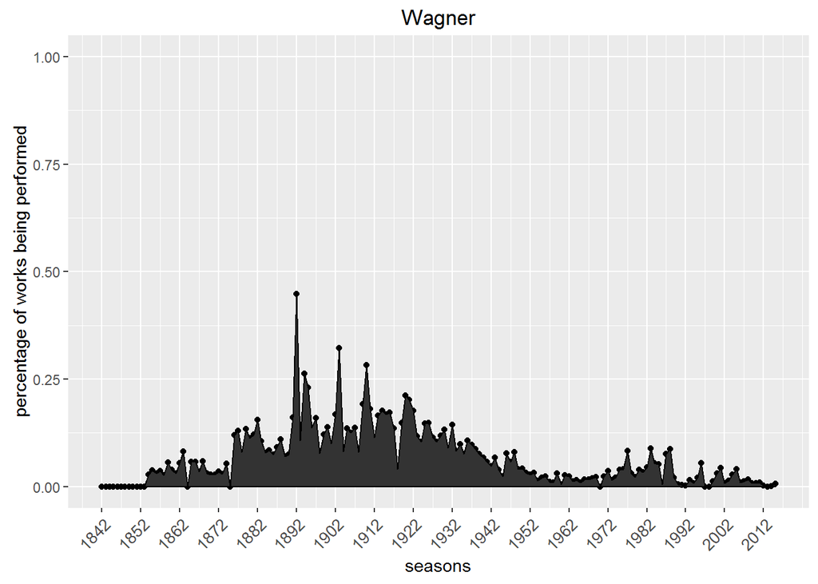

```r
wagner=as.numeric(popScoreComposerComplete[81,2:175])
qplot(seq_along(wagner),wagner)+geom_line()+ylim(0,1)+geom_area(colour="black")+scale_x_continuous(breaks=seq(1,175,10),labels=c("1842","1852","1862","1872","1882","1892","1902","1912","1922","1932","1942","1952","1962","1972","1982","1992","2002","2012"))+ theme(axis.text.x = element_text(angle = 45,size=10, hjust = 1))+xlab("seasons")+ylab("percentage of works being performed")+ggtitle("Wagner")
```

The graph shows that the normalized performance frequency score of Hitler’s favorite composer, Wagner, significantly decreased after WWII.

#### Russian

```r
russian1=read.csv("russiantest1.csv", header = FALSE ,encoding = "UTF-8")
russian2=read.csv("russiantest2.csv", header = FALSE ,encoding = "UTF-8")
russian=c(russian1,russian2)
russian=unique(unlist(russian))

russian1.0=gsub("\\(composer)","",russian)
russian1.0=gsub("\\(conductor)","",russian1.0)
russian1.1=strsplit(as.character(russian1.0)," ")

russian1.2=list(rep(0,length(russian1.1)))
for ( i in 1:length(russian1.1)){
  if (length(russian1.1[[i]])>1)
    russian1.2[i]=paste(russian1.1[[i]][length(russian1.1[[i]])],paste(russian1.1[[i]][1:length(russian1.1[[i]])-1], collapse=" "),sep=", ")
}
russian1.2=russian1.2[!is.na(russian1.2)]

test2=partialMatch(popScoreComposerComplete$composers,russian1.2)
test3=test2[-c(38,35,33,29),]
russian1.3=test3$raw.x
save(russian1.3,file="russianComps.RData")
```

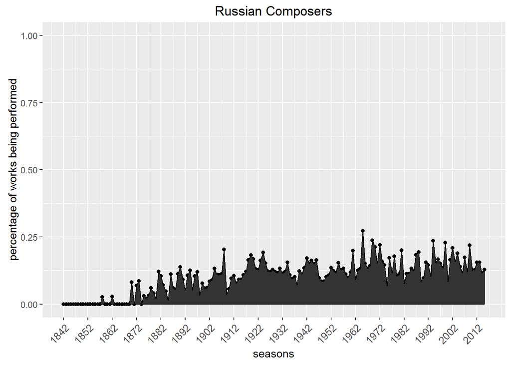

```r
load("russianComps.RData")
l=c()
for ( i in 1:length(russian1.3)){
  l=c(l,which(russian1.3[i]==popScoreComposerComplete$composers))
}

russian=popScoreComposerComplete$composers[l]
russianPop=popScoreComposerComplete[l,]
russianPopSum=colSums(russianPop[2:175])
qplot(seq_along(russianPopSum),russianPopSum)+geom_line()+ylim(0,1)+geom_area(colour="black")+scale_x_continuous(breaks=seq(1,175,10),labels=c("1842","1852","1862","1872","1882","1892","1902","1912","1922","1932","1942","1952","1962","1972","1982","1992","2002","2012"))+ theme(axis.text.x = element_text(angle = 45,size=10, hjust = 1))+xlab("seasons")+ylab("percentage of works being performed")+ggtitle("Russian Composers")
```

```r
russianTop=rowSums(russianPop[2:175],na.rm=TRUE)
russianTop=cbind(as.data.frame(russian)[1],russianTop)
russianTop1=russianTop[order(-russianTop$russianTop),]
head(russianTop1,20)
```

```
##                        russian russianTop
## 163  Tchaikovsky, Pyotr Ilyich 6.99180157
## 674          Prokofiev, Sergei 1.96598135
## 507           Stravinsky, Igor 1.90049596
## 97           Rubinstein, Anton 1.36266053
## 293   Rimsky-Korsakov, Nikolai 1.15265340
## 402       Rachmaninoff, Sergei 0.99593005
## 306          Musorgsky, Modest 0.91984703
## 880       Shostakovich, Dmitri 0.79719267
## 171            Glinka, Mikhail 0.28872620
## 268         Borodin, Alexander 0.28650337
## 274        Glazunov, Alexander 0.21893883
## 349            Lyadov, Anatoli 0.18966145
## 613  Ippolitov-Ivanov, Mikhail 0.13273524
## 1154        Kabalevsky, Dmitri 0.11512099
## 384        Scriabin, Alexander 0.10815199
## 1872        Gubaidulina, Sofia 0.05401867
## 1880         Schnittke, Alfred 0.05137547
## 797        Miaskovsky, Nikolai 0.01705590
## 1657         Shchedrin, Rodion 0.01485431
## 310        Tcherepnin, Nikolai 0.01083683
```

The graph shows that there is an increase in normalized performance frequency score of Russian composers after WWII during the cold war, probably because many important Russian composers rise during that time. This shows that the cold war did not affect the introduction of Russian music to the US.

In conclusion, overt war and internal censorship may affect cultural performances and people’s attitudes toward music, but vaguer antipathy, as in the Cold War, may not influence the frequency of cultural performances. This is reflected on the choice of NY Phil reportories. During the culture revolution in China, Western art works are strictly prohibited. Censorship affected Chinese music and art institutions’ reportorie choice. Comparing China to the United States, it suggests that, in a democratic society, attitudes and censureship somestimes do not affect art and culture performance much which is shown by the proportion of Russian works being performed increasing during the cold war. However, during actual wartime attitudes do affect art and culture performances, which is shown by the proportion of German composers’ performances diminishing during and after the war years.

#### Chinese

In order to see how the economic rise of Asia and Latin American countries affect the performance history at NY Phil, I needed to come up with a coherent list of Asian and Latin American composers. But I could not find these data. Instead, I used China as a single-country sample to see how the performance trends change over time as the economy of China rose.

In order to do that, I find a list of common Chinese last names and mathced it with composers’ last names. This matching algorithm finds every composers with Chinese ethnitiy rather than with actual Chinese nationality.

```r
url <- 'http://www.bloomberg.com/visual-data/best-and-worst//most-common-in-china-surnames'
html <- read_html(url, encoding = "UTF-8")
tables <- html_table(html, fill=TRUE)
tables=tables[[1]]
lastNames=tables["Pinyin annotation"]
ChineseLname=unlist(lastNames$`Pinyin annotation`)
ChineseLname[73]="Dun"
save(ChineseLname,file="ChineseLastName.RData")
```

```r
load("ChineseLastName.RData")
splitname=strsplit(popScoreComposerComplete$composers,",")
lname=c()
for ( i in 1:length(splitname)){
  lname=c(lname,splitname[[i]][1])
}

l=c()
for ( i in 1:length(ChineseLname)){
   l=c(l,which(ChineseLname[i]==lname))
}

asianPop=popScoreComposerComplete[l,]
nrow(asianPop)
```

```
## [1] 33
```

```r
nrow(asianPop)/nrow(popScoreComposerComplete)
```

```
## [1] 0.01244344
```

```r
asianTop=rowSums(asianPop[2:175],na.rm=TRUE)
asianTop=cbind(as.data.frame(asianPop)[1],asianTop)
asianTop1=asianTop[order(-asianTop$asianTop),]
head(unique(asianTop1),20)
```

```
##            composers    asianTop
## 2060        Dun, Tan 0.031725904
## 1708     Li, Huanzhi 0.013238389
## 1660        Chen, N. 0.005479452
## 2416    Chen, Qigang 0.003221623
## 2624    Liu, Tianhua 0.003044140
## 2604       Zhao, Lin 0.003044140
## 2595    Liao, Shuwen 0.003044140
## 2456   Zhang, Qianyi 0.001639344
## 2455    Ye, Xiaogang 0.001639344
## 2454        Qian, Qi 0.001639344
## 2417 Zhou, Chenglong 0.001582278
## 2418     Sun, Yiqian 0.001582278
## 2603   Yan, Hai-Deng 0.001522070
## 2563        Wang, Lu 0.001377410
## 2574     Wang, A-Mao 0.001377410
## 2521     Xu, Peidong 0.001377410
## 2520    Luo, Xiuying 0.001377410
## 2519   Bai, Chengren 0.001377410
## 2522   Lei, Zhenbang 0.001377410
## 2366       Ding, Qin 0.001335113
```

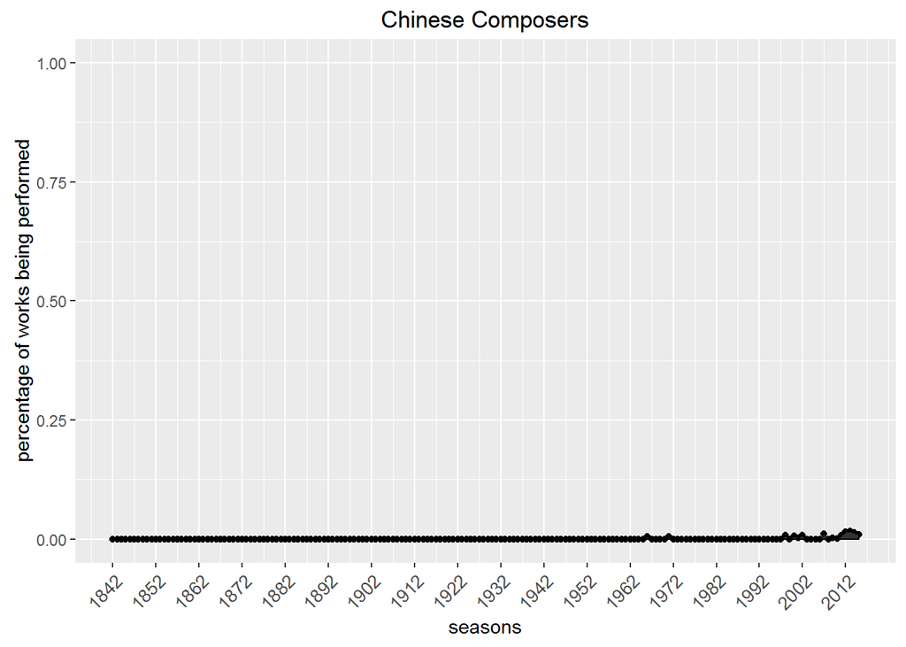

```r
asian=popScoreComposerComplete$composers[l]
asianPop=popScoreComposerComplete[l,]
asianPopSum=colSums(asianPop[2:175])
qplot(seq_along(asianPopSum),asianPopSum)+geom_line()+ylim(0,1)+geom_area(colour="black")+scale_x_continuous(breaks=seq(1,175,10),labels=c("1842","1852","1862","1872","1882","1892","1902","1912","1922","1932","1942","1952","1962","1972","1982","1992","2002","2012"))+ theme(axis.text.x = element_text(angle = 45,size=10, hjust = 1))+xlab("seasons")+ylab("percentage of works being performed")+ggtitle("Chinese Composers")
```

The graph shows that as the economy of China rose, the proportion of Chinese composers’ works being performed did not increase significantly over time. I expect the reason to be not only are there not many Chinese composeres but also there are culture communication barriers between China and the United States. As the economy of China develops, there are more and more Chinese musicians as more money and effort is put into music and art education. However, most of them are performers rather than composers. Western music and western music education was introduced to China only after the beginning of the twentieth century, so the history of western music is still relatively short in China. In addition, during the culture revolution, China was again isolated from the rest of the world. Therefore, even though there are good Chinese composers, their works are not introduced to the US.

#### French

I also did French and Italian composers performance hisotry graphs over time in order to compare them with MoMA exhibition history data.

```r
french1=read.csv("frenchtest1.csv", header = FALSE ,encoding = "UTF-8")
french2=read.csv("frenchtest2.csv", header = FALSE ,encoding = "UTF-8")
french3=read.csv("frenchtest3.csv", header = FALSE ,encoding = "UTF-8")
french4=read.csv("frenchtest4.csv", header = FALSE ,encoding = "UTF-8")
french=c(french1,french2,french3,french4)
french=unique(unlist(french))

french1.0=gsub("\\(composer)","",french)
french1.0=gsub("\\(conductor)","",french1.0)
french1.0=gsub("\\(1907???1970)","",french1.0)
french1.0=gsub("\\(organist)","",french1.0)
french1.0=gsub("\\(violist)","",french1.0)
french1.0=gsub("\\(musician) ","",french1.0)
french1.0=gsub("\\(Chantilly Codex composer) ","",french1.0)
french1.0=gsub("\\(lutenist)  ","",french1.0)
french1.1=strsplit(as.character(french1.0)," ")

french1.2=list(rep(0,length(french1.1)))
for ( i in 1:length(french1.1)){
  if (length(french1.1[[i]])>1)
    french1.2[i]=paste(french1.1[[i]][length(french1.1[[i]])],paste(french1.1[[i]][1:length(french1.1[[i]])-1], collapse=" "),sep=", ")
}
french1.2=french1.2[!is.na(french1.2)]

test2=partialMatch(popScoreComposerComplete$composers,french1.2)
test3=test2[-c(95,98,90,82,83,86,87,88,90),]
french1.3=test3$raw.x
save(french1.3,file="frenchComps.RData")
```

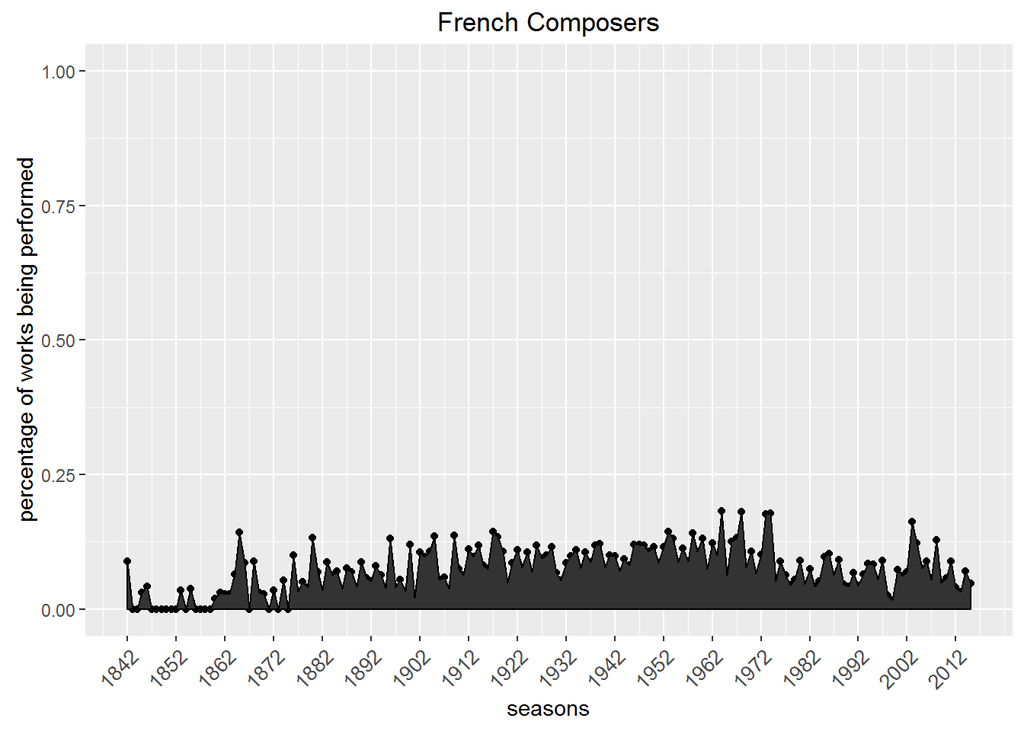

```r
load("frenchComps.RData")
l=c()
for ( i in 1:length(french1.3)){
  l=c(l,which(french1.3[i]==popScoreComposerComplete$composers))
}

french=popScoreComposerComplete$composers[l]
frenchPop=popScoreComposerComplete[l,]
frenchPopSum=colSums(frenchPop[2:175])
qplot(seq_along(frenchPopSum),frenchPopSum)+geom_line()+ylim(0,1)+geom_area(colour="black")+scale_x_continuous(breaks=seq(1,175,10),labels=c("1842","1852","1862","1872","1882","1892","1902","1912","1922","1932","1942","1952","1962","1972","1982","1992","2002","2012"))+ theme(axis.text.x = element_text(angle = 45,size=10, hjust = 1))+xlab("seasons")+ylab("percentage of works being performed")+ggtitle("French Composers")
```

```r
frenchTop=rowSums(frenchPop[2:175],na.rm=TRUE)
frenchTop=cbind(as.data.frame(french)[1],frenchTop)
frenchTop1=frenchTop[order(-frenchTop$frenchTop),]
head(frenchTop1,20)
```

```
##                    french  frenchTop
## 37        Berlioz, Hector 3.88238857
## 400        Ravel, Maurice 1.85075377
## 359       Debussy, Claude 1.74291685
## 187        Bizet, Georges 0.97999200
## 211         Lalo, Edouard 0.62961466
## 204       Massenet, Jules 0.37918047
## 125       Gounod, Charles 0.37308761
## 503    Offenbach, Jacques 0.31662581
## 401           Dukas, Paul 0.30650214
## 298    Chabrier, Emmanuel 0.24573813
## 197      Thomas, Ambroise 0.17276699
## 164 Rameau, Jean-Philippe 0.15965696
## 361      Chausson, Ernest 0.12786807
## 279  Charpentier, Gustave 0.12354508
## 743      Honegger, Arthur 0.12243434
## 768      Poulenc, Francis 0.11586613
## 792       Milhaud, Darius 0.10732493
## 369      Indy, Vincent d' 0.09896675
## 506       Roussel, Albert 0.09466475
## 790        Ibert, Jacques 0.08922502
```

#### Italian

```r
itallian1=read.csv("italiantest1.csv", header = FALSE ,encoding = "UTF-8")
itallian2=read.csv("italiantest2.csv", header = FALSE ,encoding = "UTF-8")
itallian3=read.csv("italiantest3.csv", header = FALSE ,encoding = "UTF-8")
itallian4=read.csv("italiantest4.csv", header = FALSE ,encoding = "UTF-8")
itallian5=read.csv("italiantest5.csv", header = FALSE ,encoding = "UTF-8")
italian=c(itallian1,itallian2,itallian3,itallian4,itallian5)
italian=unique(unlist(italian))

italian1.0=gsub("\\(composer)","",italian)
italian1.0=gsub("\\(conductor)","",italian1.0)
italian1.0=gsub("\\(classical era composer)","",italian1.0)
italian1.0=gsub("\\ (senior)","",italian1.0)
italian1.1=strsplit(as.character(italian1.0)," ")

italian1.2=list(rep(0,length(italian1.1)))
for ( i in 1:length(italian1.1)){
  if (length(italian1.1[[i]])>1)
    italian1.2[i]=paste(italian1.1[[i]][length(italian1.1[[i]])],paste(italian1.1[[i]][1:length(italian1.1[[i]])-1], collapse=" "),sep=", ")
}
italian1.2=italian1.2[!is.na(italian1.2)]

test2=partialMatch(popScoreComposerComplete$composers,italian1.2)
test3=test2[-c(115,114,108,107),]
italian1.3=test3$raw.x
save(italian1.3,file="italianComps.RData")
```

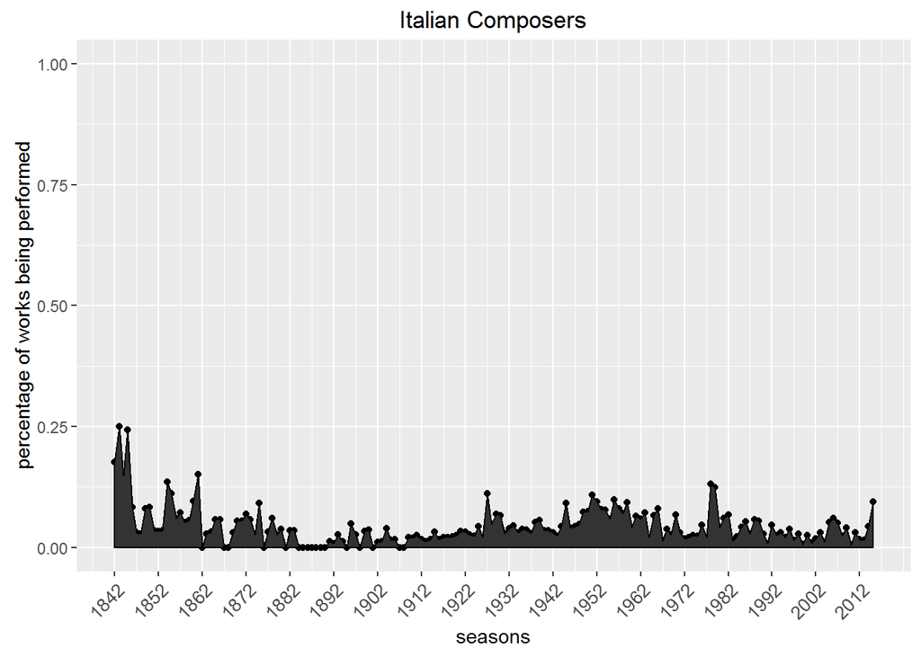

```r
load("italianComps.RData")

l=c()
for ( i in 1:length(italian1.3)){
  l=c(l,which(italian1.3[i]==popScoreComposerComplete$composers))
}

italian=popScoreComposerComplete$composers[l]
italianPop=popScoreComposerComplete[l,]
italianPopSum=colSums(italianPop[2:175])
qplot(seq_along(italianPopSum),italianPopSum)+geom_line()+ylim(0,1)+geom_area(colour="black")+scale_x_continuous(breaks=seq(1,175,10),labels=c("1842","1852","1862","1872","1882","1892","1902","1912","1922","1932","1942","1952","1962","1972","1982","1992","2002","2012"))+ theme(axis.text.x = element_text(angle = 45,size=10, hjust = 1))+xlab("seasons")+ylab("percentage of works being performed")+ggtitle("Italian Composers")
```

```r
italianTop=rowSums(italianPop[2:175],na.rm=TRUE)
italianTop=cbind(as.data.frame(italian)[1],italianTop)
italianTop1=italianTop[order(-italianTop$italianTop),]
head(italianTop1,20)
```

```
##                    italian italianTop
## 4       Rossini, Gioachino 1.47566775
## 38         Verdi, Giuseppe 1.19659419
## 18      Donizetti, Gaetano 0.79645028
## 28        Cherubini, Luigi 0.52236674
## 324       Puccini, Giacomo 0.45827854
## 7        Bellini, Vincenzo 0.39002577
## 623     Respighi, Ottorino 0.36888394
## 447       Vivaldi, Antonio 0.31968527
## 9         Pacini, Giovanni 0.12573211
## 175      Boccherini, Luigi 0.11569680
## 987     Gabrieli, Giovanni 0.10727565
## 1123   Menotti, Gian Carlo 0.09173476
## 1673        Berio, Luciano 0.08432223
## 260   Leoncavallo, Ruggero 0.08249445
## 448  Wolf-Ferrari, Ermanno 0.07725418
## 58       Spontini, Gasparo 0.06869369
## 621       Casella, Alfredo 0.05634322
## 413      Busoni, Ferruccio 0.05435054
## 558   Ponchielli, Amilcare 0.05359123
## 311       Mascagni, Pietro 0.05318986
```

#### The status of Women Composers

The feminist movements accelerated in 1960s. It first starts in political and economic equality between men and women, and spread to the culture sectors. Can we find this reflected in NY Phil performance data?

I cannot find a comprehensive list of woman composers in the world. I took American composer as a smaple and examined the proportion of American womem composers’ work being performed over time by NY Phil. To do this, I scraped this page (http://names.mongabay.com/female_names.htm) and got a list of common American female first names and matched them with the NY Phil record.

```r
url <- 'http://names.mongabay.com/female_names.htm'
html <- read_html(url, encoding = "UTF-8")
tables <- html_table(html, fill=TRUE)
tables=tables[[1]]
femalename=tables[1]
femalename=femalename[1:500,]
femalenames=tolower(femalename)
save(femalenames,file="femalenames.RData")
```

```r
load("femalenames.RData")
names=americansPop[1]$composers
splitName2=strsplit(names,",")
fname=c()
for (i in 1:length(splitName2)){
  fname=c(fname,splitName2[[i]][2])
}
fname=tolower(fname)
fname=trimws(fname)
fname3=strsplit(fname," ")
fname4=c()
for (i in 1: length(fname3)){
  fname4=c(fname4,fname3[[i]][1])
}


l=c()
for ( i in 1:length(femalenames)){
   l=c(l,which(femalenames[i]==fname4))
}

woman=americansPop[l,1]
woman
```

```
##  [1] "Howe, Mary"             "Wood, Mary Knight"
##  [3] "Kolb, Barbara"          "Bonds, Margaret"
##  [5] "Moore, Dorothy Rudd"    "Drattell, Deborah"
##  [7] "Beach, Amy"             "Berger, Jean"
##  [9] "Tower, Joan"            "Perry, Julia"
## [11] "Wolfe, Julia"           "Coolidge, Peggy Stuart"
## [13] "Zwilich, Ellen Taaffe"  "Oliveros, Pauline"
## [15] "Bassett, Leslie"        "Kubik, Gail"
## [17] "Spiegel, Laurie"        "Wagner, Melinda"
## [19] "Riley, Terry"           "Daniels, Mabel Wheeler"
## [21] "Swift, Kay"             "Willson, Meredith"
## [23] "Soper, Kate"            "Dlugoszewski, Lucia"
```

```r
womanTrue=woman[-c(8,15,16,19,22)]
womanTrue
```

```
##  [1] "Howe, Mary"             "Wood, Mary Knight"
##  [3] "Kolb, Barbara"          "Bonds, Margaret"
##  [5] "Moore, Dorothy Rudd"    "Drattell, Deborah"
##  [7] "Beach, Amy"             "Tower, Joan"
##  [9] "Perry, Julia"           "Wolfe, Julia"
## [11] "Coolidge, Peggy Stuart" "Zwilich, Ellen Taaffe"
## [13] "Oliveros, Pauline"      "Spiegel, Laurie"
## [15] "Wagner, Melinda"        "Daniels, Mabel Wheeler"
## [17] "Swift, Kay"             "Soper, Kate"
## [19] "Dlugoszewski, Lucia"
```

```r
length(womanTrue)/nrow(americansPop)
```

```
## [1] 0.06506849
```

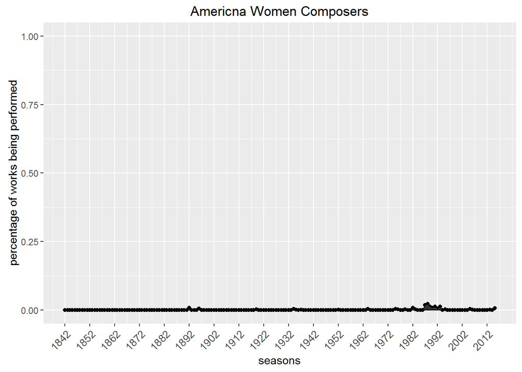

```r
womanPop=americansPop[l,]
womanPop=womanPop[-c(8,15,16,19,22),]
womanPopSum=colSums(womanPop[2:175])
qplot(seq_along(womanPopSum),womanPopSum)+geom_line()+ylim(0,1)+geom_area(colour="black")+scale_x_continuous(breaks=seq(1,175,10),labels=c("1842","1852","1862","1872","1882","1892","1902","1912","1922","1932","1942","1952","1962","1972","1982","1992","2002","2012"))+ theme(axis.text.x = element_text(angle = 45,size=10, hjust = 1))+xlab("seasons")+ylab("percentage of works being performed")+ggtitle("Americna Women Composers")
```

There are also some gender neutral names in the female first name list. Thus, some of the people in the list could be male. I removed them by hand. The graph shows that as time changes, the proportion of women composers’ works being performed did not increase significantly over time, which reflects the sad situation of women in classical music.

#### Art from MoMA

To compare with how NY Phil performance history reflects the change of American society, I decide to do a series of MoMA exhibition history graphs by country.

```r
require(dplyr)
MoMA=read.csv("MoMA.csv",header=TRUE,encoding = "UTF-8")
moma.1=MoMA[,c("Nationality","Date")][1:98578,]
moma.1$Date.1=as.numeric(gsub("([0-9]+).*$", "\\1", moma.1$Date))
moma.1=na.omit(moma.1)
moma.1=moma.1[,c("Nationality", "Date.1")]
write.csv(moma.1,"momaSmall.csv")
```

```r
moma.1=read.csv("momaSmall.csv",row.names=1)
moma.1=subset(moma.1, Date.1>=1929)

test=unique(moma.1$Date.1)

test=sort(test)
tyear=rep(0,length(test))
soviet=rep(0,length(test))
american=rep(0,length(test))
germanAustria=rep(0,length(test))
french=rep(0,length(test))
italian=rep(0,length(test))
asianLatin=rep(0,length(test))

psoviet=rep(0,length(test))
pamerican=rep(0,length(test))
pgermanAustria=rep(0,length(test))
pfrench=rep(0,length(test))
pitalian=rep(0,length(test))
pasianLatin=rep(0,length(test))

for ( i in 1:length(test)){
  tyear[i]=unlist(nrow(subset(moma.1,Date.1==test[i])))
  american[i]=length(grep("American",subset(moma.1,Date.1==test[i])$Nationality))+length(grep("USA",subset(moma.1,Date.1==test[i])$Nationality))
  pamerican[i]=as.numeric(american[i])/as.numeric(tyear[i])

   soviet[i]=length(grep("Russian",subset(moma.1,Date.1==test[i])$Nationality))
  psoviet[i]=as.numeric(soviet[i])/as.numeric(tyear[i])

  germanAustria[i]=length(grep("German",subset(moma.1,Date.1==test[i])$Nationality))

  pgermanAustria[i]=as.numeric(germanAustria[i])/as.numeric(tyear[i])

  french[i]=length(grep("French",subset(moma.1,Date.1==test[i])$Nationality))
  pfrench[i]=as.numeric(french[i])/as.numeric(tyear[i])

  italian[i]=length(grep("Italian",subset(moma.1,Date.1==test[i])$Nationality))
  pitalian[i]=as.numeric(italian[i])/as.numeric(tyear[i])

   asianLatin[i]=length(grep("Chinese",subset(moma.1,Date.1==test[i])$Nationality))
  pasianLatin[i]=as.numeric(asianLatin[i])/as.numeric(tyear[i])
}
```

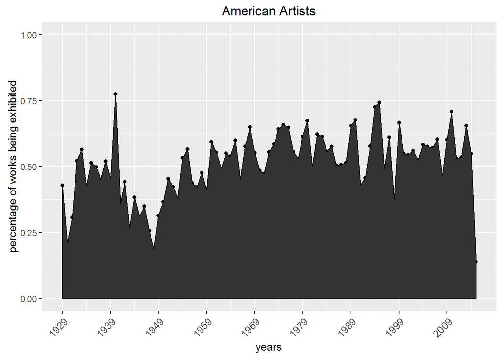

```r
qplot(seq_along(pamerican),pamerican)+geom_line()+ylim(0,1)+geom_area(colour="black")+ theme(axis.text.x = element_text(angle = 45,size=10, hjust = 1))+scale_x_continuous(breaks=seq(1,90,by=10),labels=c("1929","1939","1949","1959","1969","1979","1989","1999","2009"))+xlab("years")+ylab("percentage of works being exhibited")+ggtitle("American Artists")
```

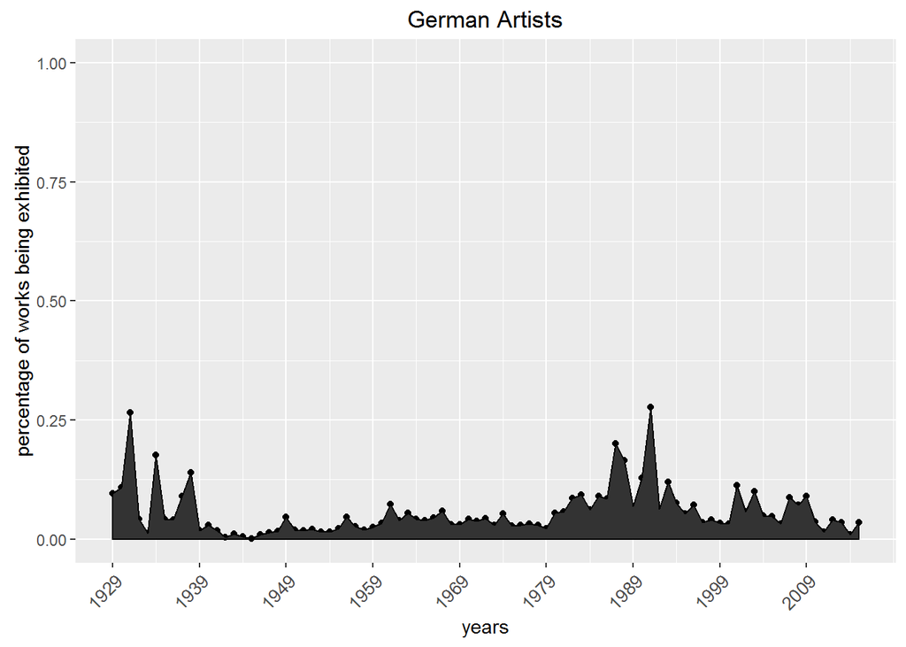

```r
qplot(seq_along(pgermanAustria),pgermanAustria)+geom_line()+ylim(0,1)+geom_area(colour="black")+ theme(axis.text.x = element_text(angle = 45,size=10, hjust = 1))+scale_x_continuous(breaks=seq(1,90,by=10),labels=c("1929","1939","1949","1959","1969","1979","1989","1999","2009"))+xlab("years")+ylab("percentage of works being exhibited")+ggtitle("German Artists")
```

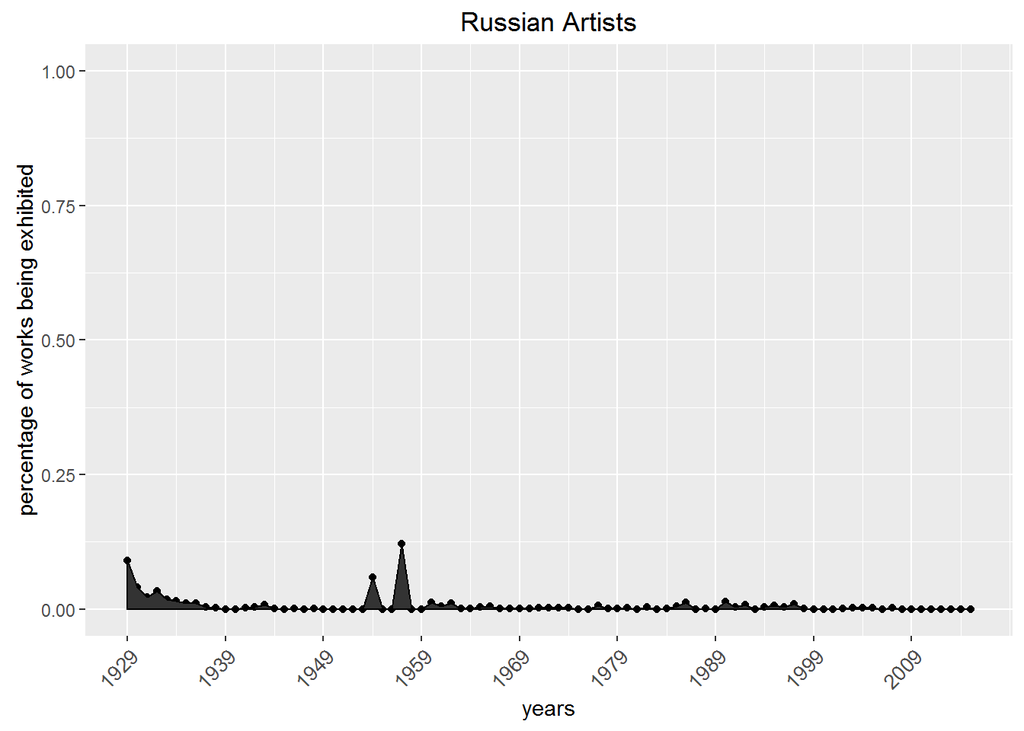

```r
qplot(seq_along(psoviet),psoviet)+geom_line()+ylim(0,1)+geom_area(colour="black")+ theme(axis.text.x = element_text(angle = 45,size=10, hjust = 1))+scale_x_continuous(breaks=seq(1,90,by=10),labels=c("1929","1939","1949","1959","1969","1979","1989","1999","2009"))+xlab("years")+ylab("percentage of works being exhibited")+ggtitle("Russian Artists")
```

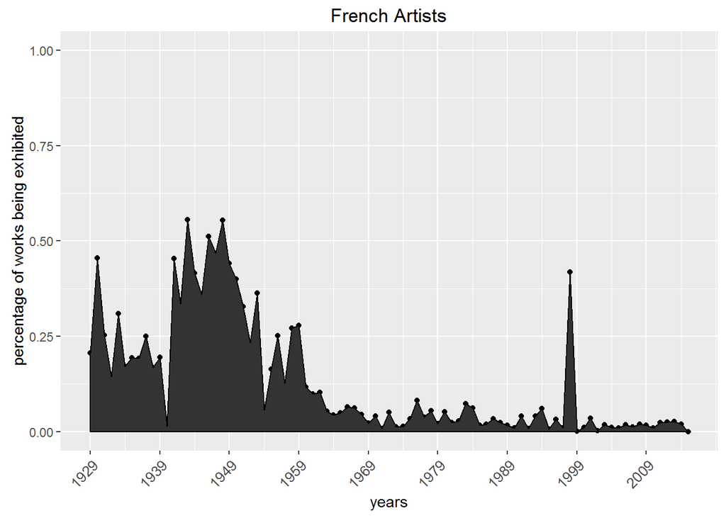

```r
qplot(seq_along(pfrench),pfrench)+geom_line()+ylim(0,1)+geom_area(colour="black")+ theme(axis.text.x = element_text(angle = 45,size=10, hjust = 1))+scale_x_continuous(breaks=seq(1,90,by=10),labels=c("1929","1939","1949","1959","1969","1979","1989","1999","2009"))+xlab("years")+ylab("percentage of works being exhibited")+ggtitle("French Artists")
```

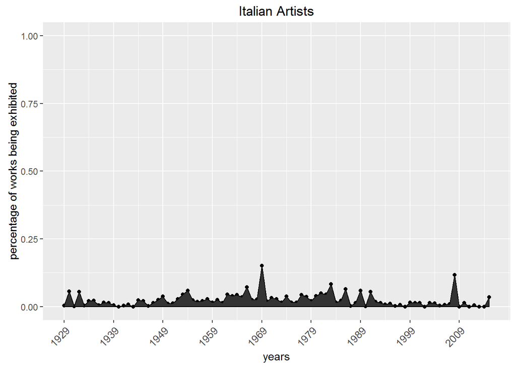

```r
qplot(seq_along(pitalian),pitalian)+geom_line()+ylim(0,1)+geom_area(colour="black")+ theme(axis.text.x = element_text(angle = 45,size=10, hjust = 1))+scale_x_continuous(breaks=seq(1,90,by=10),labels=c("1929","1939","1949","1959","1969","1979","1989","1999","2009"))+xlab("years")+ylab("percentage of works being exhibited")+ggtitle("Italian Artists")
```

```r
sum(asianLatin)
```

```
## [1] 110
```

```r
sum(asianLatin)/nrow(moma.1)
```

```
## [1] 0.00180618
```

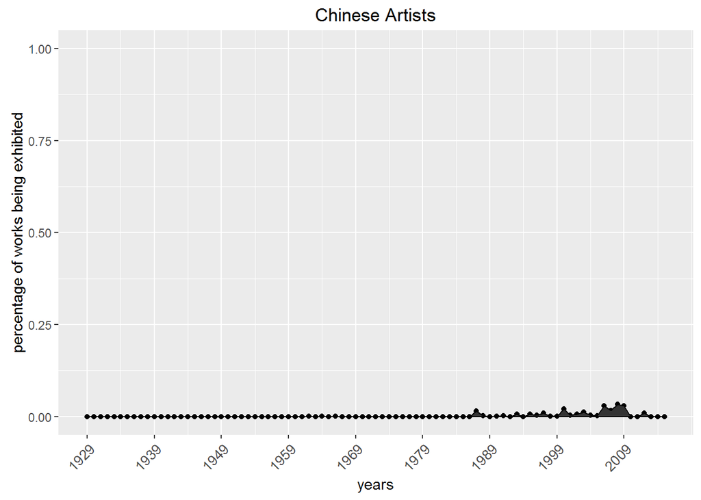

```r
qplot(seq_along(pasianLatin),pasianLatin)+geom_line()+ylim(0,1)+geom_area(colour="black")+ theme(axis.text.x = element_text(angle = 45,size=10, hjust = 1))+scale_x_continuous(breaks=seq(1,90,by=10),labels=c("1929","1939","1949","1959","1969","1979","1989","1999","2009"))+xlab("years")+ylab("percentage of works being exhibited")+ggtitle("Chinese Artists")
```

the graphs show that MoMA exhibition history is more sensitive to changes in US social pressures than the NY Philharmoic performance history. For example, during WWII, the exhibitions of German artists’ work at MoMA are very infrequent. But later, before and after Berlin Wall fell when Americans had lots of sympathy for Germans, there is a big peak in the frequency of German artists’ exhibitions. The fluctuation is smaller for the NY Phil composer-frequency data when compared with the peaks in MoMA’s exhibition frequency data.  
This might be because art, as relected by curatorial and exhibition selections, is actually more sensitive to social pressures than are choices of music to perform. Alternatively, it might because MoMA’s exhibits are recent and contemporary while the NY Phil concerts include a much longer history of music and this long history somehoe dilutes the effects of social attitudes. For example, Americans did not hate German music from Beethoven’s era.

### Conclusion

In this project, I studied the performance history of the NY Philharmonic and analyzed the trends of performance frequency by composer nationality and gender as a function of social attitudes derived from states of war, hostility and censorship. I also compared NY Phil performance data with MoMA exhibition data and found MoMA exhibition data to be even more sensitive to such social attitude pressures. This project tells the story of the NY Philharmonic’s performance history and tries to explain how changes in its repertoire are related to changes in social attitudes in American history. This is my first attempt to bring quantitative analysis to bear on a field in the humanities.

### future work

I would like to graph some individual NY Phil performer or composer’s performance history to show how he or she rose to stardom over time. Is there a steady rise in the number of performances or are there any up and downs. In addition, I’d like to study the proportion of composers whose works are performed at NY Phil during their own lifetimes. Furthur, I’d like to see if any global art and culture trends like impressionism and popularity of Ballet Russe corresponds NY Phil performance history and MoMA exhibition history. In addition, I do want to point out that in this research I am relying on internet sources esepcially Wikipedia pages for composers’ personal information. I believe that crowd intelligence can be reliable, but because these are not authorized sources, there must be some mistakes in the content. I caught some of them and corrected them by hand, but there might be some other faults in the sources which I did not catch. If I have more time and the resouces, I’d do the same study trying from authenticated sources for composers’ nationalities and women gender and compare it with my study based on wikipeida pages, which can be a way to see how reliable crowd intelligence is.

### Achnolwegement

I thank Yoav Bergner for introducing me to the wonderful world of data science. I thank Vincent Dorie for teaching me debugging techniques. And I thank George Robinson for moral support and critical review.